# The Effects of Music-Induced Arousal and Music Sensitivity on Attention and Mood

- Show All Code
- Hide All Code
- View Source

PSY 120L Reproducible Analysis Report

Author

Melina Zachou

Published

June 7, 2026

## About This Report

This reproducible report shows how raw data is prepared and how variables are reconstructed in order to obtain data statistics and perform analyses, which includes figures for this study.

This report will accompany a research paper; it is important to note that this is not the paper itself, but rather, shows how the statistics and analyses listed in the report were obtained from the raw dataset.

## Study Overview

This study examined whether attention and mood differed by music condition, music sensitivity group, and their interaction.

The design included one manipulated independent variable and one categorical moderator:

- Music condition: silence control versus high-arousal music
- Music sensitivity group: lower music sensitivity versus higher music sensitivity

The dependent variables were Flanker Effect scores, positive affect scores, and negative affect scores.

The primary analyses tested whether music condition, music sensitivity group, and their interaction predicted each outcome.

## Setup and Software Environment

The goal of this section is to load the packages that will be used throughout the report, including data preparation, variable creation, statistical analyses, results, and figures.

**Load Packages**

```r
library(tidyverse)  # data manipulation + plotting
library(psych)      # scale construction + reliability
library(afex)       # ANOVA models + effect sizes
library(emmeans)    # estimated marginal means + confidence intervals
```

## Data Source and Analysis Dataset

The dataset was imported from the project data folder. The imported dataset was saved as raw_data so that the original file remained unchanged throughout the report.

A smaller analysis dataset was then created for the current analyses. This dataset retained the condition and demographic variables, Flanker performance scores, music reward items, and positive and negative affect items needed for the analyses.

```r
raw_data <- read_csv("data/raw_data.csv")
```

### Check Imported Dataset

```r
dim(raw_data)
```

```
[1] 99 52
```

```r
names(raw_data)
```

```
 [1] "Finished"          "Consent Form"      "Q287_First Click"
 [4] "Q287_Last Click"   "Q287_Page Submit"  "Q287_Click Count"
 [7] "Compatible Score"  "Incongruent Score" "FlankerEffect"
[10] "soc1"              "seek2"             "emo3"
[13] "mood4"             "sens5"             "soc6"
[16] "seek7"             "emo8"              "mood9"
[19] "sens10"            "seek11"            "emo12"
[22] "soc13"             "mood14"            "sens15"
[25] "soc16"             "seek17"            "emo18"
[28] "mood19"            "sens20"            "pos1"
[31] "neg2"              "pos3"              "neg4"
[34] "pos5"              "neg6"              "neg7"
[37] "neg8"              "pos9"              "pos10"
[40] "neg11"             "neg12"             "neg13"
[43] "pos14"             "neg15"             "pos16"
[46] "pos17"             "neg18"             "pos19"
[49] "neg20"             "age"               "gender"
[52] "condition"
```

```r
head(raw_data)
```

```
# A tibble: 6 × 52
  Finished `Consent Form` `Q287_First Click` `Q287_Last Click`
     <dbl>          <dbl>              <dbl>             <dbl>
1        1              1                 NA                NA
2        1              1                 NA                NA
3        1              1                  0                 0
4        1              1                  0                 0
5        1              1                 NA                NA
6        1              1                  0                 0
# ℹ 48 more variables: `Q287_Page Submit` <dbl>, `Q287_Click Count` <dbl>,
#   `Compatible Score` <chr>, `Incongruent Score` <chr>, FlankerEffect <chr>,
#   soc1 <dbl>, seek2 <dbl>, emo3 <dbl>, mood4 <dbl>, sens5 <dbl>, soc6 <dbl>,
#   seek7 <dbl>, emo8 <dbl>, mood9 <dbl>, sens10 <dbl>, seek11 <dbl>,
#   emo12 <dbl>, soc13 <dbl>, mood14 <dbl>, sens15 <dbl>, soc16 <dbl>,
#   seek17 <dbl>, emo18 <dbl>, mood19 <dbl>, sens20 <dbl>, pos1 <dbl>,
#   neg2 <dbl>, pos3 <dbl>, neg4 <dbl>, pos5 <dbl>, neg6 <dbl>, neg7 <dbl>, …
```

The import checks confirm that the dataset loaded successfully and provide an overview of its structure, including the number of rows, columns, and available variables.

### Clean Flanker Item

```r
raw_data <- raw_data %>%
  mutate(
    FlankerEffect = str_remove(FlankerEffect, "ms"),
    FlankerEffect = as.numeric(FlankerEffect),
    FlankerEffect = if_else(
      abs(FlankerEffect) > 500,
      NA_real_,
      FlankerEffect
    )
  )

raw_data %>%
  summarise(
    mean_flanker = mean(FlankerEffect, na.rm = TRUE),
    sd_flanker = sd(FlankerEffect, na.rm = TRUE),
    min_flanker = min(FlankerEffect, na.rm = TRUE),
    max_flanker = max(FlankerEffect, na.rm = TRUE),
    missing_flanker = sum(is.na(FlankerEffect))
  ) %>%
  knitr::kable()
```

| mean_flanker | sd_flanker | min_flanker | max_flanker | missing_flanker |
| --- | --- | --- | --- | --- |
| 27.8 | 78.8895 | -162 | 199 | 39 |

### Create Analysis Dataset

```r
study_vars <- c(

      "gender", "age", "condition",

      "Compatible Score",
      "Incongruent Score",
      "FlankerEffect",

      "emo3", "emo8", "emo12", "emo18",
      "seek2", "seek7", "seek11", "seek17",
      "sens5", "sens10", "sens15", "sens20",
      "soc1", "soc6", "soc13", "soc16",
      "mood4", "mood9", "mood14", "mood19",

      "pos1", "pos3", "pos5", "pos9", "pos10",
      "pos14", "pos16", "pos17", "pos19",

      "neg2", "neg4", "neg6", "neg7", "neg8", "neg11",
      "neg12", "neg13", "neg15", "neg18", "neg20"

      )

clean_data <- raw_data %>%
  select(all_of(study_vars)) %>%
  mutate(
    across(everything(), as.numeric)
  )
```

The output below lists the variables retained in the final analysis dataset. These variables include demographic information (gender and age), the experimental condition, Flanker task performance measures, BMRQ items used to assess music reward sensitivity, and PANAS items used to measure positive and negative affect.

### Check Analysis Dataset

```r
length(study_vars)
```

```
[1] 46
```

```r
dim(clean_data)
```

```
[1] 99 46
```

```r
names(clean_data)
```

```
 [1] "gender"            "age"               "condition"
 [4] "Compatible Score"  "Incongruent Score" "FlankerEffect"
 [7] "emo3"              "emo8"              "emo12"
[10] "emo18"             "seek2"             "seek7"
[13] "seek11"            "seek17"            "sens5"
[16] "sens10"            "sens15"            "sens20"
[19] "soc1"              "soc6"              "soc13"
[22] "soc16"             "mood4"             "mood9"
[25] "mood14"            "mood19"            "pos1"
[28] "pos3"              "pos5"              "pos9"
[31] "pos10"             "pos14"             "pos16"
[34] "pos17"             "pos19"             "neg2"
[37] "neg4"              "neg6"              "neg7"
[40] "neg8"              "neg11"             "neg12"
[43] "neg13"             "neg15"             "neg18"
[46] "neg20"
```

The analysis dataset contains the variables required for the report. The checks confirm the number of selected variables, the dimensions of the analysis dataset, and the final variable names carried forward into the preparation and analysis sections.

## Variable Preparation

This section prepares the variables used in the primary analyses. The original imported dataset was left unchanged; all prepared variables were created in the working analysis dataset, clean_data.

### Prepare Participant ID and Experimental Condition

```r
clean_data <- clean_data %>%
  mutate(
    id = row_number(),
    condition = factor(
      condition,
      levels = c(0, 1),
      labels = c("Control", "Arousal")
    ))
```

The condition variable was converted to a labeled factor with the levels Control and Arousal. A unique participant ID was also generated for each row in the dataset to facilitate data management and analysis.

### Check Experimental Condition Coding

```r
clean_data %>%
  count(condition) %>%
  knitr::kable(
    col.names = c("Condition", "n")
  )
```

| Condition | n |
| --- | --- |
| Control | 47 |
| Arousal | 47 |
| NA | 5 |

The condition frequencies were examined to verify that the experimental condition variable was recoded correctly and that participants were appropriately assigned to the Control and Arousal groups.

### Check Prepared Analysis Dataset

```r
dim(clean_data)
```

```
[1] 99 47
```

```r
names(clean_data)
```

```
 [1] "gender"            "age"               "condition"
 [4] "Compatible Score"  "Incongruent Score" "FlankerEffect"
 [7] "emo3"              "emo8"              "emo12"
[10] "emo18"             "seek2"             "seek7"
[13] "seek11"            "seek17"            "sens5"
[16] "sens10"            "sens15"            "sens20"
[19] "soc1"              "soc6"              "soc13"
[22] "soc16"             "mood4"             "mood9"
[25] "mood14"            "mood19"            "pos1"
[28] "pos3"              "pos5"              "pos9"
[31] "pos10"             "pos14"             "pos16"
[34] "pos17"             "pos19"             "neg2"
[37] "neg4"              "neg6"              "neg7"
[40] "neg8"              "neg11"             "neg12"
[43] "neg13"             "neg15"             "neg18"
[46] "neg20"             "id"
```

The output below confirms that the prepared analysis dataset contains the expected number of observations and variables and lists all variables retained for subsequent analyses.

### Reverse-Code Scale Items

The BMRQ items requiring reverse coding were transformed prior to scale construction. Because these items were measured on a 1–5 response scale, reverse-coded values were created by subtracting each original response from 6 so that higher scores consistently reflected greater music reward sensitivity.

```r
clean_data <- clean_data %>%
  mutate(

        seek2r = 6 - seek2,
        sens5r = 6 - sens5

  )
```

### Check Reverse Coding

```r
clean_data %>%
  select(seek2, seek2r, sens5, sens5r) %>%
  head(10) %>%
  knitr::kable()
```

| seek2 | seek2r | sens5 | sens5r |
| --- | --- | --- | --- |
| 2 | 4 | 1 | 5 |
| 1 | 5 | 2 | 4 |
| 1 | 5 | 1 | 5 |
| 1 | 5 | 2 | 4 |
| 4 | 2 | 3 | 3 |
| 3 | 3 | 2 | 4 |
| 1 | 5 | 1 | 5 |
| 1 | 5 | 1 | 5 |
| 2 | 4 | 3 | 3 |
| 1 | 5 | 1 | 5 |

### Create Scale Scores

Scale item lists were defined and used to compute composite scores for music reward sensitivity (BMRQ), positive affect, and negative affect.

```r
bmrq_items <- c(
            "emo3", "emo8", "emo12", "emo18", "seek2r", "seek7",
            "seek11", "seek17", "sens5r", "sens10", "sens15",
            "sens20", "soc1", "soc6", "soc13", "soc16","mood4",
            "mood9", "mood14", "mood19"
          )

positive_affect_items <- c(
            "pos1", "pos3", "pos5", "pos9", "pos10",
            "pos14", "pos16", "pos17", "pos19"
          )

negative_affect_items <- c(
            "neg2", "neg4", "neg6", "neg7", "neg8",
            "neg11", "neg12", "neg13", "neg15", "neg18", "neg20"
        )


clean_data <- clean_data %>%
  mutate(
    bmrq_scale = rowMeans(across(all_of(bmrq_items)), na.rm = TRUE),
    positive_affect = rowMeans(across(all_of(positive_affect_items)), na.rm = TRUE),
    negative_affect = rowMeans(across(all_of(negative_affect_items)), na.rm = TRUE)
  )
```

### Check Scale Scores

```r
clean_data %>%
  select(
    bmrq_scale,
    positive_affect,
    negative_affect
  ) %>%
  summary()
```

```
   bmrq_scale    positive_affect negative_affect
 Min.   :2.450   Min.   :1.000   Min.   :1.000
 1st Qu.:3.612   1st Qu.:1.694   1st Qu.:1.182
 Median :4.050   Median :2.333   Median :1.455
 Mean   :3.935   Mean   :2.375   Mean   :1.620
 3rd Qu.:4.300   3rd Qu.:2.889   3rd Qu.:1.818
 Max.   :5.000   Max.   :4.111   Max.   :3.909
 NA's   :37      NA's   :37      NA's   :37
```

```r
clean_data %>%
  summarise(
    bmrq_scale_missing = mean(is.na(bmrq_scale)),
    postive_affect_missing = mean(is.na(positive_affect)),
    negative_affect_missing = mean(is.na(negative_affect))
  ) %>%
  knitr::kable()
```

| bmrq_scale_missing | postive_affect_missing | negative_affect_missing |
| --- | --- | --- |
| 0.3737374 | 0.3737374 | 0.3737374 |

The summary statistics below provide the minimum, maximum, quartiles, mean, and number of missing values for each computed scale score. These checks were used to verify that the scale scores were calculated correctly and fell within their expected ranges.

### Create BMRQ Median Split

```r
bmrq_median <- median(clean_data$bmrq_scale, na.rm = TRUE)

clean_data <- clean_data %>%
mutate(
    bmrq_msplit = if_else(bmrq_scale <= bmrq_median, "Low", "High"),
    bmrq_msplit = factor(bmrq_msplit, levels = c("Low", "High"))
    )

bmrq_median
```

```
[1] 4.05
```

```r
clean_data %>%
  count(bmrq_msplit) %>%
  knitr::kable(
    col.names = c("Commitment Group", "n")
  )
```

| Commitment Group | n |
| --- | --- |
| Low | 34 |
| High | 28 |
| NA | 37 |

### Check Scale Reliability

Internal consistency was evaluated for the Music Reward Sensitivity (BMRQ), Positive Affect, and Negative Affect scales before the scale scores were used in the primary analyses.

```r
bmrq_item_df <- clean_data %>% select(all_of(bmrq_items))
positive_affect_item_df <- clean_data %>% select(all_of(positive_affect_items))
negative_affect_item_df <- clean_data %>% select(all_of(negative_affect_items))

bmrq_alpha <- psych::alpha(bmrq_item_df)
bmrq_omega <- psych::omega(bmrq_item_df, plot = FALSE)

positive_affect_alpha <- psych::alpha(positive_affect_item_df)
positive_affect_omega <- psych::omega(positive_affect_item_df, plot = FALSE)

negative_affect_alpha <- psych::alpha(negative_affect_item_df)
negative_affect_omega <- psych::omega(negative_affect_item_df, plot = FALSE)

reliability_table <- tibble(
  scale = c("Music Sensitivity", "Positive Affect", "Negative Affect"),
  alpha = c(
    bmrq_alpha$total$raw_alpha,
    positive_affect_alpha$total$raw_alpha,
    negative_affect_alpha$total$raw_alpha
  ),
  omega = c(
    bmrq_omega$omega.tot,
    positive_affect_omega$omega.tot,
    negative_affect_omega$omega.tot
  )
)

reliability_table %>%
  mutate(
    alpha = round(alpha, 2),
    omega = round(omega, 2)
  ) %>%
  knitr::kable(
    col.names = c("Scale", "Cronbach's alpha", "McDonald's omega")
  )
```

| Scale | Cronbach’s alpha | McDonald’s omega |
| --- | --- | --- |
| Music Sensitivity | 0.91 | 0.94 |
| Positive Affect | 0.89 | 0.92 |
| Negative Affect | 0.89 | 0.92 |

The results indicate strong internal consistency for all three scales. Cronbach’s alpha values ranged from .89 to .91, and McDonald’s omega values ranged from .92 to .94, suggesting that the Music Sensitivity, Positive Affect, and Negative Affect scales demonstrated good to excellent reliability in the current sample.

## Descriptive Statistics

This section summarizes the distributions of the study variables and describes the characteristics of the sample prior to the primary analyses.

### Scale Score Descriptives

```r
# Descriptive statistics for continuous scale variables
clean_data %>%
  select(bmrq_scale, positive_affect, negative_affect, FlankerEffect) %>%
  psych::describe() %>%
  knitr::kable(digits = 2)
```

|  | vars | n | mean | sd | median | trimmed | mad | min | max | range | skew | kurtosis | se |
| --- | --- | --- | --- | --- | --- | --- | --- | --- | --- | --- | --- | --- | --- |
| bmrq_scale | 1 | 62 | 3.94 | 0.58 | 4.05 | 3.97 | 0.44 | 2.45 | 5.00 | 2.55 | -0.68 | 0.09 | 0.07 |
| positive_affect | 2 | 62 | 2.37 | 0.76 | 2.33 | 2.35 | 0.82 | 1.00 | 4.11 | 3.11 | 0.18 | -0.86 | 0.10 |
| negative_affect | 3 | 62 | 1.62 | 0.62 | 1.45 | 1.52 | 0.40 | 1.00 | 3.91 | 2.91 | 1.59 | 2.53 | 0.08 |
| FlankerEffect | 4 | 60 | 27.80 | 78.89 | 21.50 | 27.31 | 65.23 | -162.00 | 199.00 | 361.00 | 0.10 | -0.26 | 10.18 |

The table reports descriptive statistics for Music Reward Sensitivity (BMRQ), Positive Affect, Negative Affect, and Flanker Effect scores used in the primary analyses.

### Sample Composition by Age and Gender

```r
clean_data %>%
  summarise(
    mean_age = round(mean(age, na.rm = TRUE), 2),
    sd_age = round(sd(age, na.rm = TRUE), 2),
    min_age = min(age, na.rm = TRUE),
    max_age = max(age, na.rm = TRUE)
  ) %>%
  knitr::kable(
    col.names = c("Mean Age", "SD Age", "Minimum Age", "Maximum Age")
  )
```

| Mean Age | SD Age | Minimum Age | Maximum Age |
| --- | --- | --- | --- |
| 23.77 | 9.17 | 18 | 64 |

```r
clean_data %>%
  mutate(
    gender = factor(gender,
      levels = c(1, 2, 3, 4),
      labels = c(
        "Male",
        "Female",
        "Non-binary / third gender",
        "Prefer not to say"
      )
    )
  )
```

```
# A tibble: 99 × 53
   gender   age condition `Compatible Score` `Incongruent Score` FlankerEffect
   <fct>  <dbl> <fct>                  <dbl>               <dbl>         <dbl>
 1 Female    22 Arousal                  802                 899            97
 2 Female    21 Arousal                  601                 582           -19
 3 Female    22 Control                  622                 639            17
 4 Female    20 Control                  592                 587            -5
 5 Female    25 Arousal                  593                 651            58
 6 Female    20 Control                  665                 737            72
 7 Female    22 Arousal                  594                 633            39
 8 Female    22 Arousal                  612                 677            65
 9 Female    20 Control                   NA                  NA            23
10 Female    21 Arousal                  619                 785           166
# ℹ 89 more rows
# ℹ 47 more variables: emo3 <dbl>, emo8 <dbl>, emo12 <dbl>, emo18 <dbl>,
#   seek2 <dbl>, seek7 <dbl>, seek11 <dbl>, seek17 <dbl>, sens5 <dbl>,
#   sens10 <dbl>, sens15 <dbl>, sens20 <dbl>, soc1 <dbl>, soc6 <dbl>,
#   soc13 <dbl>, soc16 <dbl>, mood4 <dbl>, mood9 <dbl>, mood14 <dbl>,
#   mood19 <dbl>, pos1 <dbl>, pos3 <dbl>, pos5 <dbl>, pos9 <dbl>, pos10 <dbl>,
#   pos14 <dbl>, pos16 <dbl>, pos17 <dbl>, pos19 <dbl>, neg2 <dbl>, …
```

```r
clean_data %>%
 count(gender) %>%
 mutate(percent = round(100 * n / sum(n), 1)) %>%
 knitr::kable()
```

| gender | n | percent |
| --- | --- | --- |
| 1 | 12 | 12.1 |
| 2 | 49 | 49.5 |
| NA | 38 | 38.4 |

The sample was primarily composed of participants who identified as female (49.5%), followed by male participants (12.1%). A substantial proportion of participants (38.4%) did not report their gender, resulting in missing data for this demographic variable.

## Correlations Among the DVs

Pearson correlation analyses were conducted to examine the relationships among the primary continuous study variables, including Flanker Effect, Positive Affect, and Negative Affect. Correlation coefficients and associated significance tests were computed to assess the strength and direction of these associations.

```r
# Correlations for the main continuous dependent variables
psych::corr.test(
  clean_data %>%
    select(
      FlankerEffect,
      positive_affect,
      negative_affect
    )
)
```

```
Call:psych::corr.test(x = clean_data %>% select(FlankerEffect, positive_affect,
    negative_affect))
Correlation matrix
                FlankerEffect positive_affect negative_affect
FlankerEffect            1.00            0.07            0.01
positive_affect          0.07            1.00            0.42
negative_affect          0.01            0.42            1.00
Sample Size
                FlankerEffect positive_affect negative_affect
FlankerEffect              60              60              60
positive_affect            60              62              62
negative_affect            60              62              62
Probability values (Entries above the diagonal are adjusted for multiple tests.)
                FlankerEffect positive_affect negative_affect
FlankerEffect            0.00               1               1
positive_affect          0.62               0               0
negative_affect          0.93               0               0

 To see confidence intervals of the correlations, print with the short=FALSE option
```

The correlation analyses revealed a moderate positive association between Positive Affect and Negative Affect (r = .42, p < .001). However, Flanker Effect scores were not significantly related to Positive Affect (r = .07, p = .62) or Negative Affect (r = .01, p = .93). These results suggest that affective measures were associated with one another, whereas Flanker task performance showed little relationship with either affect measure in the current sample.

## Primary Analyses

This section reports the primary analyses used to examine whether music condition, Music Reward Sensitivity, and their interaction predicted Flanker task performance and affective outcomes.

Three 2 × 2 ANOVA models were estimated. The first model used Flanker Effect scores as the dependent variable, the second model used Positive Affect scores as the dependent variable, and the third model used Negative Affect scores as the dependent variable. In each model, music condition (Control vs. Arousal) served as the manipulated independent variable and Music Reward Sensitivity group served as the categorical moderator.

### Flanker Attention Model

A 2 × 2 ANOVA was used to test the effects of music condition, Music Reward Sensitivity group, and their interaction on Flanker Effect scores.

```r
a1_flanker <- afex::aov_ez(
  id = "id",
  dv = "FlankerEffect",
  between = c("condition", "bmrq_msplit"),
  data = clean_data
)

a1_flanker
```

```
Anova Table (Type 3 tests)

Response: FlankerEffect
                 Effect    df     MSE      F  ges p.value
1             condition 1, 56 6039.43 3.65 + .061    .061
2           bmrq_msplit 1, 56 6039.43   0.66 .012    .422
3 condition:bmrq_msplit 1, 56 6039.43   0.09 .002    .770
---
Signif. codes:  0 '***' 0.001 '**' 0.01 '*' 0.05 '+' 0.1 ' ' 1
```

The ANOVA table reports the main effect of music condition, the main effect of Music Reward Sensitivity group, and the music condition × Music Reward Sensitivity group interaction for Flanker Effect scores.

### Estimated Means for Flanker Attention

```r
emmeans(a1_flanker, ~ condition)
```

```
 condition emmean   SE df lower.CL upper.CL
 Control     7.28 14.4 56    -21.6     36.2
 Arousal    46.17 14.3 56     17.5     74.9

Results are averaged over the levels of: bmrq_msplit
Confidence level used: 0.95
```

```r
emmeans(a1_flanker, ~ bmrq_msplit)
```

```
 bmrq_msplit emmean   SE df lower.CL upper.CL
 Low           35.0 13.7 56     7.54     62.4
 High          18.5 15.0 56   -11.66     48.6

Results are averaged over the levels of: condition
Confidence level used: 0.95
```

```r
emmeans(a1_flanker, ~ condition * bmrq_msplit)
```

```
 condition bmrq_msplit emmean   SE df lower.CL upper.CL
 Control   Low          18.50 20.8 56   -23.11     60.1
 Arousal   Low          51.42 17.8 56    15.71     87.1
 Control   High         -3.93 20.1 56   -44.13     36.3
 Arousal   High         40.92 22.4 56    -4.02     85.9

Confidence level used: 0.95
```

The estimated marginal means summarize Flanker Effect scores across levels of music condition, Music Reward Sensitivity group, and their combined condition × Music Reward Sensitivity group cells.

### Positive Mood Model

A 2 × 2 ANOVA was conducted to examine whether Positive Affect scores differed as a function of music condition, Music Reward Sensitivity group, and their interaction.

```r
a1_positive_affect <- afex::aov_ez(
  id = "id",
  dv = "positive_affect",
  between = c("condition", "bmrq_msplit"),
  data = clean_data
)

a1_positive_affect
```

```
Anova Table (Type 3 tests)

Response: positive_affect
                 Effect    df  MSE    F  ges p.value
1             condition 1, 58 0.60 0.72 .012    .401
2           bmrq_msplit 1, 58 0.60 0.44 .008    .508
3 condition:bmrq_msplit 1, 58 0.60 0.93 .016    .339
---
Signif. codes:  0 '***' 0.001 '**' 0.01 '*' 0.05 '+' 0.1 ' ' 1
```

The ANOVA table summarizes the effects of music condition, Music Reward Sensitivity group, and their interaction on Positive Affect scores.

### Estimated Means for Positive Mood

```r
emmeans(a1_positive_affect, ~ condition)
```

```
 condition emmean    SE df lower.CL upper.CL
 Control     2.30 0.141 58     2.02     2.59
 Arousal     2.47 0.139 58     2.19     2.75

Results are averaged over the levels of: bmrq_msplit
Confidence level used: 0.95
```

```r
emmeans(a1_positive_affect, ~ bmrq_msplit)
```

```
 bmrq_msplit emmean    SE df lower.CL upper.CL
 Low           2.32 0.133 58     2.05     2.59
 High          2.45 0.146 58     2.16     2.75

Results are averaged over the levels of: condition
Confidence level used: 0.95
```

```r
emmeans(a1_positive_affect, ~ condition * bmrq_msplit)
```

```
 condition bmrq_msplit emmean    SE df lower.CL upper.CL
 Control   Low           2.33 0.199 58     1.93     2.73
 Arousal   Low           2.31 0.177 58     1.96     2.66
 Control   High          2.27 0.199 58     1.88     2.67
 Arousal   High          2.63 0.214 58     2.20     3.06

Confidence level used: 0.95
```

The estimated marginal means provide adjusted group means for Positive Affect scores across music condition, Music Reward Sensitivity group, and their interaction, facilitating interpretation of the ANOVA results.

### Negative Mood Model

A 2 × 2 ANOVA was conducted to examine whether Negative Affect scores differed as a function of music condition, Music Reward Sensitivity group, and their interaction.

```r
a1_negative_affect <- afex::aov_ez(
  id = "id",
  dv = "negative_affect",
  between = c("condition", "bmrq_msplit"),
  data = clean_data
)

a1_negative_affect
```

```
Anova Table (Type 3 tests)

Response: negative_affect
                 Effect    df  MSE    F   ges p.value
1             condition 1, 58 0.40 0.08  .001    .778
2           bmrq_msplit 1, 58 0.40 0.00 <.001    .966
3 condition:bmrq_msplit 1, 58 0.40 0.40  .007    .530
---
Signif. codes:  0 '***' 0.001 '**' 0.01 '*' 0.05 '+' 0.1 ' ' 1
```

The ANOVA table summarizes the effects of music condition, Music Reward Sensitivity group, and their interaction on Negative Affect scores.

### Estimated Means for Negative Mood

```r
emmeans(a1_negative_affect, ~ condition)
```

```
 condition emmean    SE df lower.CL upper.CL
 Control     1.65 0.115 58     1.42     1.88
 Arousal     1.60 0.113 58     1.38     1.83

Results are averaged over the levels of: bmrq_msplit
Confidence level used: 0.95
```

```r
emmeans(a1_negative_affect, ~ bmrq_msplit)
```

```
 bmrq_msplit emmean    SE df lower.CL upper.CL
 Low           1.63 0.109 58     1.41     1.85
 High          1.62 0.119 58     1.38     1.86

Results are averaged over the levels of: condition
Confidence level used: 0.95
```

```r
emmeans(a1_negative_affect, ~ condition * bmrq_msplit)
```

```
 condition bmrq_msplit emmean    SE df lower.CL upper.CL
 Control   Low           1.70 0.163 58     1.38     2.03
 Arousal   Low           1.56 0.145 58     1.27     1.84
 Control   High          1.59 0.163 58     1.27     1.92
 Arousal   High          1.65 0.175 58     1.30     2.00

Confidence level used: 0.95
```

The estimated marginal means provide adjusted group means for Negative Affect scores across music condition, Music Reward Sensitivity group, and their interaction, facilitating interpretation of the ANOVA results.

## Figures

This section presents the figures used to visualize the primary 2 × 2 ANOVA results. The plots display the estimated marginal means for Flanker Effect, Positive Affect, and Negative Affect scores across music condition and Music Reward Sensitivity group.

### Flanker Attentin Interaction Plot

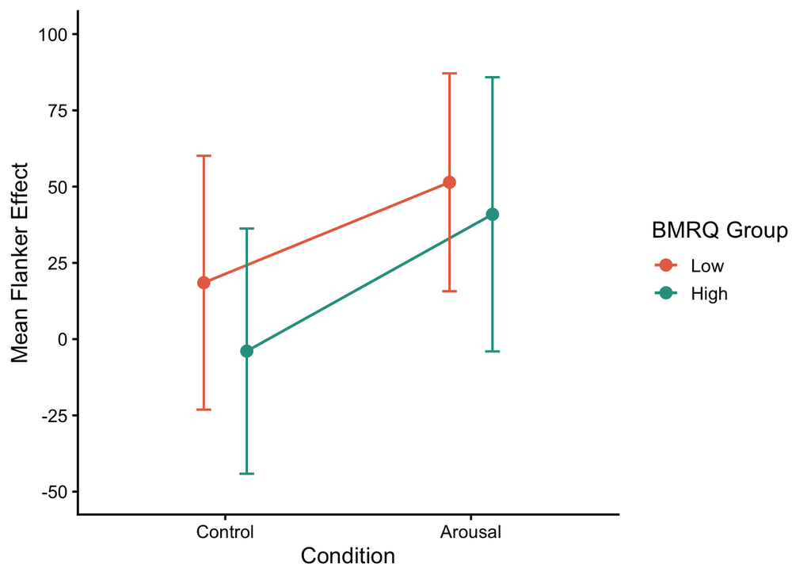

```r
p_flanker_condition_bmrq_bar <- ggplot(
  as.data.frame(emmeans(a1_flanker, ~ condition * bmrq_msplit)),
  aes(
    x = condition,
    y = emmean,
    color = bmrq_msplit,
    group = bmrq_msplit
  )
) +
  geom_point(
    position = position_dodge(width = 0.35),
    size = 3
  ) +
  geom_line(
    position = position_dodge(width = 0.35),
    linewidth = 0.8
  ) +
  geom_errorbar(
    aes(
      ymin = lower.CL,
      ymax = upper.CL
    ),
    position = position_dodge(width = 0.35),
    width = 0.12,
    linewidth = 0.7
  ) +
  labs(
    x = "Condition",
    y = "Mean Flanker Effect",
    color = "BMRQ Group"
  ) +
  scale_color_manual(
    values = c(
      "Low" = "#E76F51",
      "High" = "#2A9D8F"
    )
  ) +
  scale_y_continuous(
    breaks = seq(-50, 100, 25)
  ) +
  coord_cartesian(
    ylim = c(-50, 100)
  ) +
  theme_classic(
    base_size = 14
  )

p_flanker_condition_bmrq_bar
```

The figure displays the estimated marginal means of Flanker Effect scores across music condition and Music Reward Sensitivity group. Error bars represent 95% confidence intervals around the estimated means.

### Positive Affect Interaction Plot

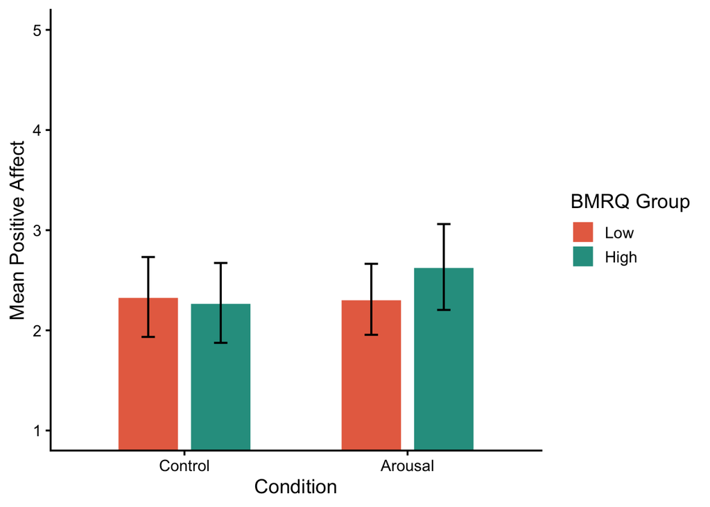

```r
p_positive_affect_condition_bmrq_bar <- ggplot(
  as.data.frame(emmeans(a1_positive_affect, ~ condition * bmrq_msplit)),
  aes(
    x = condition,
    y = emmean,
    fill = bmrq_msplit
  )
) +
  geom_col(
    position = position_dodge(width = 0.65),
    width = 0.55,
    color = "white"
  ) +
  geom_errorbar(
    aes(
      ymin = lower.CL,
      ymax = upper.CL
    ),
    position = position_dodge(width = 0.65),
    width = 0.12,
    linewidth = 0.7
  ) +
  labs(
    x = "Condition",
    y = "Mean Positive Affect",
    fill = "BMRQ Group"
  ) +
  scale_fill_manual(
    values = c(
      "Low" = "#E76F51",
      "High" = "#2A9D8F"
    )
  ) +
  scale_y_continuous(
    breaks = seq(1, 5, 1)
  ) +
  coord_cartesian(
    ylim = c(1, 5)
  ) +
  theme_classic(
    base_size = 14
  )

p_positive_affect_condition_bmrq_bar
```

The figure displays the estimated marginal means of Positive Affect scores across music condition and Music Reward Sensitivity group. Error bars represent 95% confidence intervals around the estimated means.

### Negative Affect Interaction Plot

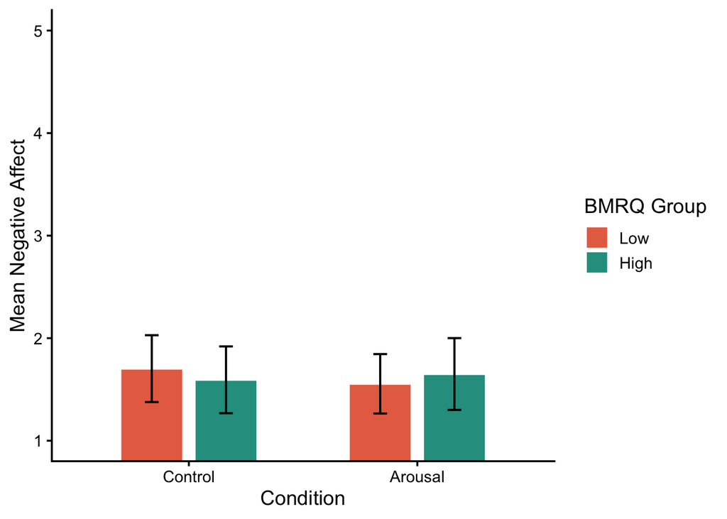

```r
p_negative_affect_condition_bmrq_bar <- ggplot(
  as.data.frame(emmeans(a1_negative_affect, ~ condition * bmrq_msplit)),
  aes(
    x = condition,
    y = emmean,
    fill = bmrq_msplit
  )
) +
  geom_col(
    position = position_dodge(width = 0.65),
    width = 0.55,
    color = "white"
  ) +
  geom_errorbar(
    aes(
      ymin = lower.CL,
      ymax = upper.CL
    ),
    position = position_dodge(width = 0.65),
    width = 0.12,
    linewidth = 0.7
  ) +
  labs(
    x = "Condition",
    y = "Mean Negative Affect",
    fill = "BMRQ Group"
  ) +
  scale_fill_manual(
    values = c(
      "Low" = "#E76F51",
      "High" = "#2A9D8F"
    )
  ) +
  scale_y_continuous(
    breaks = seq(1, 5, 1)
  ) +
  coord_cartesian(
    ylim = c(1, 5)
  ) +
  theme_classic(
    base_size = 14
  )

p_negative_affect_condition_bmrq_bar
```

The figure displays the estimated marginal means of Negative Affect scores across music condition and Music Reward Sensitivity group. Error bars represent 95% confidence intervals around the estimated means.

### Export Figures

```r
if (!dir.exists("figures")) {
  dir.create("figures")
}

ggsave(
  filename = "figures/flanker_condition_bmrq_interaction_plot.svg",
  plot = p_flanker_condition_bmrq_bar,
  width = 7,
  height = 5
)

ggsave(
  filename = "figures/positive_affect_condition_bmrq_interaction_plot.svg",
  plot = p_positive_affect_condition_bmrq_bar,
  width = 7,
  height = 5
)

ggsave(
  filename = "figures/negative_affect_condition_bmrq_interaction_plot.svg",
  plot = p_negative_affect_condition_bmrq_bar,
  width = 7,
  height = 5
)
```

The figures were exported to the figures/ folder for use in the final manuscript, poster presentation, and other project materials.

## Results Summary

The primary analyses examined whether music condition, Music Reward Sensitivity (BMRQ) group, and their interaction were associated with Flanker Effect, Positive Affect, and Negative Affect scores. Across all three models, no statistically significant main effects of music condition or BMRQ group were observed. Likewise, no statistically significant interaction effects were detected, indicating that the relationship between music condition and the outcome variables did not differ across levels of Music Reward Sensitivity.

Although some descriptive differences were evident in the estimated marginal means and interaction plots, these patterns were not large enough to reach statistical significance. Overall, the findings suggest that neither music condition nor Music Reward Sensitivity was meaningfully associated with attentional performance, positive affect, or negative affect in the present sample.